# 3.3 Finding a Regression Line

## Goals

1. Calculate and interpret a regression line.
2. Interpret a coefficient of determination.
3. Understand the relationship between a correlation coefficient and a coefficient of determination.
4. Use a regression line to make predictions.
   - Identify potential problems with predictions.

## Residuals

**Residuals** are the leftover *stuff* (variation) in the data after accounting for model fit: \[\text{data} = \text{prediction} + \text{residual}\]

## Residuals

- Each observation has its own residual.
- The residual for an observation \((x,y)\) is the difference between observed (\(y\)) and predicted (\(\hat{y}\)): \[e = y - \hat{y}\]
- We denote the residuals by \(e\) and find \(\hat{y}\) by plugging \(x\) into the regression equation.

Note: If an observation lands above the regression line, \(e > 0\). If below, \(e < 0\).

## Residuals

Goal: get each residual as close to 0 as possible.

To shrink the residuals toward 0, we minimize: \[ \begin{aligned} \sum_{i=1}^n e_i^2 &= \sum_{i=1}^n (y_i - \hat{y}_i)^2 \\ & = \sum_{i=1}^n [y_i - (b_0 + b_1 x_i)]^2 \end{aligned} \]

The values \(b_0\) and \(b_1\) that minimize this will make up our regression line.

## Finding \(b_0\) and \(b_1\)

- The slope is \[b_1 = \frac{s_y}{s_x}\times R\]
- The intercept is \[b_0 = \bar{y} - b_1 \bar{x}\]

## Example: Old Faithful Geyser in Yellowstone

- `eruptions`, the length of each eruption
- `waiting`, the time between eruptions

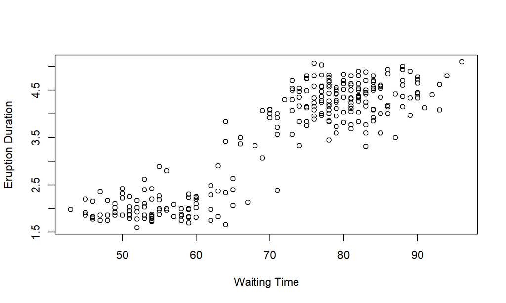

## Example: Old Faithful Geyser in Yellowstone

The sample statistics for these data are

|  | `waiting` | `eruptions` |
| --- | --- | --- |
| mean | \(\bar{x}=70.90\) | \(\bar{y}=3.49\) |
| sd | \(s_x=13.60\) | \(s_y=1.14\) |
|  |  | \(R = 0.90\) |

## Example: Old Faithful Geyser in Yellowstone

|  | `waiting` | `eruptions` |
| --- | --- | --- |
| mean | \(\bar{x}=70.90\) | \(\bar{y}=3.49\) |
| sd | \(s_x=13.60\) | \(s_y=1.14\) |
|  |  | \(R = 0.90\) |

The equation for slope is \[b_1 = \frac{s_y}{s_x}\times R\] so \[b_1 = \frac{1.14}{13.60}\times 0.90 = 0.075\]

## Example: Old Faithful Geyser in Yellowstone

|  | `waiting` | `eruptions` |
| --- | --- | --- |
| mean | \(\bar{x}=70.90\) | \(\bar{y}=3.49\) |
| sd | \(s_x=13.60\) | \(s_y=1.14\) |
|  |  | \(R = 0.90\) |

Putting these together, the regression line is \[\hat{y} = -1.83 + 0.075x\]

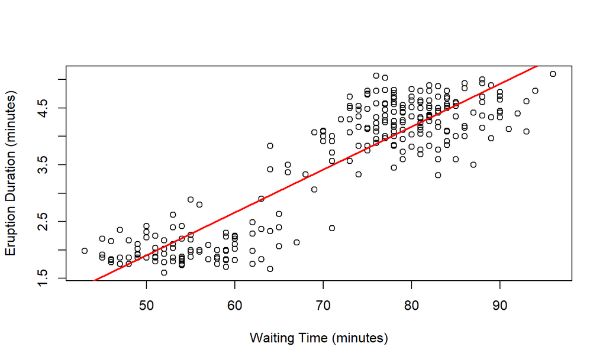

## The Coefficient of Determination

The **coefficient of determination**, \(R^2\), is the square of the correlation coefficient.

- This value tells us how much of the variability around the regression line is accounted for by the regression.
- An easy way to interpret this value is to assign it a letter grade.
  - For example, if \(R^2 = 0.84\), the predictive capabilities of the regression line get a B.

## Example: Old Faithful Geyser in Yellowstone

|  | `waiting` | `eruptions` |
| --- | --- | --- |
| mean | \(\bar{x}=70.90\) | \(\bar{y}=3.49\) |
| sd | \(s_x=13.60\) | \(s_y=1.14\) |
|  |  | \(R = 0.90\) |

Since \(R = 0.90\), we can find \(R^2 = 0.90^2 = 0.81\)

That is, 81% of the variability around the regression line is accounted for by the regression and this line gets a B

## Prediction: Some Notes

It’s important to stop and think about our predictions.

- Sometimes, the numbers just don’t make sense.
- Other times it’s harder to tell something’s wrong!

## Extrapolation

*Extrapolation* is applying a model estimate for values outside of the data’s range for \(x\).

- Our linear model is only an approximation.
  - We don’t know anything about the relationship outside of the scope of our data.

## Example

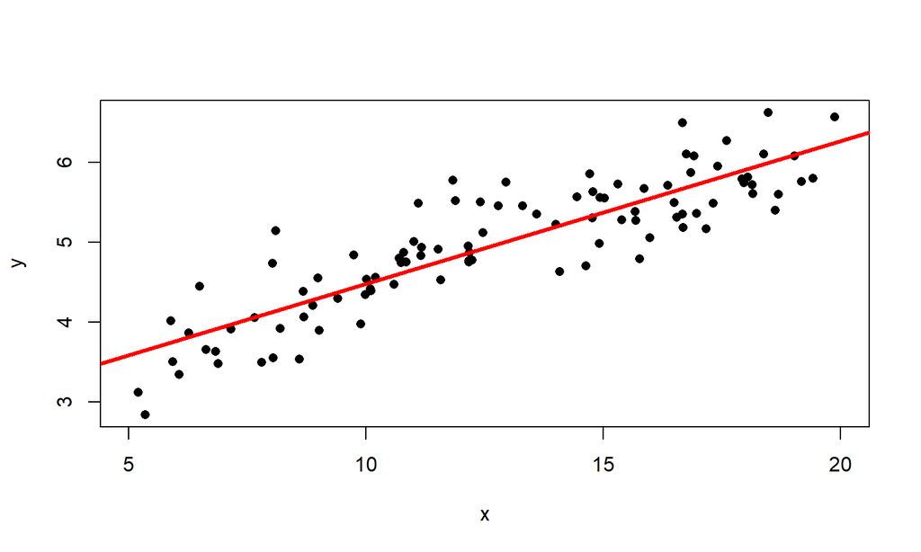

## Example

The best fit line is \[\hat{y} = 2.69 + 0.179x\]

- The correlation is \(R=0.877\).
- So the coefficient of determination is \(R^2 = 0.767\).
  - (think: a C grade)

## Prediction: Some Notes

Suppose we wanted to predict the value of \(y\) when \(x=0.1\): \[\hat{y} = 2.69 + 0.179\times0.1 = 2.71\]

## Prediction: Some Notes

This seems reasonable… but the true (population) best-fit model looks like this:

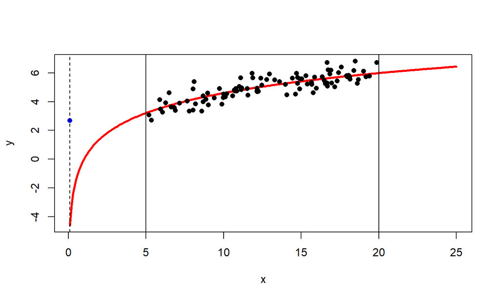